# R Notebook

##### Dataset: Online Retail.xlsx

##### Source: [Coursera] (https://www.coursera.org/projects/perform-exploratory-data-analysis-on-retail-data-with-python)

##### Objectives:

1. Assess sales trends over time (daily, monthly, yearly, day of week, seasons)
2. Assess sales trends by country (top-selling vs low-selling)
3. Assess sales trends by product (top-selling vs low-selling)
4. Determine the number of orders generated by month
5. Compare monthly revenue and monthly orders
6. Determine monthly average order value
7. Determine most valuable customer(s)
8. Determine product popularity (by country)
9. Provide an high-level view of sales performance

```r
# Install packages if they are not already installed
# install.packages(c("readxl", "dplyr", "ggplot2", "lubridate", #"stringr"))

# Load packages
library(readxl)
library(dplyr)
library(ggplot2)
library(lubridate)
library(stringr)
library(readxl)
```

```r
# Read dataset
df <- read_excel("C:/Users/dande/Downloads/Online Retail.xlsx")
```

```r
# Display top rows
head(df)
```

| InvoiceNo | StockCode | Description | Quantity | InvoiceDate | UnitPrice | CustomerID | Country |
| --- | --- | --- | --- | --- | --- | --- | --- |
| 536365 | 85123A | WHITE HANGING HEART T-LIGHT HOLDER | 6 | 2010-12-01 08:26:00 | 2.55 | 17850 | United Kingdom |
| 536365 | 71053 | WHITE METAL LANTERN | 6 | 2010-12-01 08:26:00 | 3.39 | 17850 | United Kingdom |
| 536365 | 84406B | CREAM CUPID HEARTS COAT HANGER | 8 | 2010-12-01 08:26:00 | 2.75 | 17850 | United Kingdom |
| 536365 | 84029G | KNITTED UNION FLAG HOT WATER BOTTLE | 6 | 2010-12-01 08:26:00 | 3.39 | 17850 | United Kingdom |
| 536365 | 84029E | RED WOOLLY HOTTIE WHITE HEART. | 6 | 2010-12-01 08:26:00 | 3.39 | 17850 | United Kingdom |
| 536365 | 22752 | SET 7 BABUSHKA NESTING BOXES | 2 | 2010-12-01 08:26:00 | 7.65 | 17850 | United Kingdom |

*Explanation:* The first six rows of the dataset.

```r
# Display bottom rows
tail(df)
```

| InvoiceNo | StockCode | Description | Quantity | InvoiceDate | UnitPrice | CustomerID | Country |
| --- | --- | --- | --- | --- | --- | --- | --- |
| 581587 | 23256 | CHILDRENS CUTLERY SPACEBOY | 4 | 2011-12-09 12:50:00 | 4.15 | 12680 | France |
| 581587 | 22613 | PACK OF 20 SPACEBOY NAPKINS | 12 | 2011-12-09 12:50:00 | 0.85 | 12680 | France |
| 581587 | 22899 | CHILDREN'S APRON DOLLY GIRL | 6 | 2011-12-09 12:50:00 | 2.10 | 12680 | France |
| 581587 | 23254 | CHILDRENS CUTLERY DOLLY GIRL | 4 | 2011-12-09 12:50:00 | 4.15 | 12680 | France |
| 581587 | 23255 | CHILDRENS CUTLERY CIRCUS PARADE | 4 | 2011-12-09 12:50:00 | 4.15 | 12680 | France |
| 581587 | 22138 | BAKING SET 9 PIECE RETROSPOT | 3 | 2011-12-09 12:50:00 | 4.95 | 12680 | France |

*Explanation:* The last six rows of the dataset.

```r
# Examine dataset structure
str(df)
```

```
tibble [541,909 × 8] (S3: tbl_df/tbl/data.frame)
 $ InvoiceNo  : chr [1:541909] "536365" "536365" "536365" "536365" ...
 $ StockCode  : chr [1:541909] "85123A" "71053" "84406B" "84029G" ...
 $ Description: chr [1:541909] "WHITE HANGING HEART T-LIGHT HOLDER" "WHITE METAL LANTERN" "CREAM CUPID HEARTS COAT HANGER" "KNITTED UNION FLAG HOT WATER BOTTLE" ...
 $ Quantity   : num [1:541909] 6 6 8 6 6 2 6 6 6 32 ...
 $ InvoiceDate: POSIXct[1:541909], format: "2010-12-01 08:26:00" "2010-12-01 08:26:00" "2010-12-01 08:26:00" ...
 $ UnitPrice  : num [1:541909] 2.55 3.39 2.75 3.39 3.39 7.65 4.25 1.85 1.85 1.69 ...
 $ CustomerID : num [1:541909] 17850 17850 17850 17850 17850 ...
 $ Country    : chr [1:541909] "United Kingdom" "United Kingdom" "United Kingdom" "United Kingdom" ...
```

*Explanation* The columns in the dataset & their corresponding datatypes are: - InvoiceNo: character - StockCode: character - Description: character - Quantity: numeric - InvoiceDate: datetime - UnitPrice: numeric - CustomerID: numeric - Country: character

```r
# Display no. of rows and columns
dim(df)
```

```
[1] 541909      8
```

*Explanation:* The dataset has 541909 rows and 8 columns.

```r
# Display descriptive stats
summary(df)
```

```
     InvoiceNo          StockCode         Description        Quantity
 Length   :541909   Length   :541909   Length   :541909   Min.   :-80995.000
 N.unique : 25900   N.unique :  4070   N.unique :  4211   1st Qu.:     1.000
 N.blank  :     0   N.blank  :     0   N.blank  :     0   Median :     3.000
 Min.nchar:     6   Min.nchar:     1   Min.nchar:     1   Mean   :     9.552
 Max.nchar:     7   Max.nchar:    12   Max.nchar:    35   3rd Qu.:    10.000
                                       NAs      :  1454   Max.   : 80995.000

  InvoiceDate                    UnitPrice            CustomerID          Country
 Min.   :2010-12-01 08:26:00   Min.   :-11062.060   Min.   :12346    Length   :541909
 1st Qu.:2011-03-28 11:34:00   1st Qu.:     1.250   1st Qu.:13953    N.unique :    38
 Median :2011-07-19 17:17:00   Median :     2.080   Median :15152    N.blank  :     0
 Mean   :2011-07-04 13:34:57   Mean   :     4.611   Mean   :15288    Min.nchar:     3
 3rd Qu.:2011-10-19 11:27:00   3rd Qu.:     4.130   3rd Qu.:16791    Max.nchar:    20
 Max.   :2011-12-09 12:50:00   Max.   : 38970.000   Max.   :18287
                                                    NAs    :135080
```

*Explanation:* For columns of ‘character’ datatype, statistics of length, number of unique values, number of blank values, minimum character length and maximum character length are shown. Conversely, for columns of ‘numeric’ and ‘datetime’ datatype, the minimum, 1st quartile (25% mark), median, mean, 3rd quartile (75% mark) and maximum are shown.

```r
# Count duplicated rows
sum(duplicated(df))
```

```
[1] 5268
```

*Explanation:* 5268 duplicate rows were identified in the dataset. If kept in the analysis, these will produce inflated sales performance results.

```r
# Count missing values
colSums(is.na(df))
```

```
  InvoiceNo   StockCode Description    Quantity InvoiceDate   UnitPrice  CustomerID     Country
          0           0        1454           0           0           0      135080           0
```

*Explanation:* ‘Description’ and ‘CustomerID’ columns have 1454 and 135080 missing (NA) values, respectively.

```r
# Count transactions with negative quantities
sum(df$Quantity < 0)
```

```
[1] 10624
```

```r
# Display some negative-quantity transactions
head(
  df[df$Quantity < 0, ],
  10
)
```

| InvoiceNo | StockCode | Description | Quantity | InvoiceDate | UnitPrice | CustomerID | Country |
| --- | --- | --- | --- | --- | --- | --- | --- |
| C536379 | D | Discount | -1 | 2010-12-01 09:41:00 | 27.50 | 14527 | United Kingdom |
| C536383 | 35004C | SET OF 3 COLOURED FLYING DUCKS | -1 | 2010-12-01 09:49:00 | 4.65 | 15311 | United Kingdom |
| C536391 | 22556 | PLASTERS IN TIN CIRCUS PARADE | -12 | 2010-12-01 10:24:00 | 1.65 | 17548 | United Kingdom |
| C536391 | 21984 | PACK OF 12 PINK PAISLEY TISSUES | -24 | 2010-12-01 10:24:00 | 0.29 | 17548 | United Kingdom |
| C536391 | 21983 | PACK OF 12 BLUE PAISLEY TISSUES | -24 | 2010-12-01 10:24:00 | 0.29 | 17548 | United Kingdom |
| C536391 | 21980 | PACK OF 12 RED RETROSPOT TISSUES | -24 | 2010-12-01 10:24:00 | 0.29 | 17548 | United Kingdom |
| C536391 | 21484 | CHICK GREY HOT WATER BOTTLE | -12 | 2010-12-01 10:24:00 | 3.45 | 17548 | United Kingdom |
| C536391 | 22557 | PLASTERS IN TIN VINTAGE PAISLEY | -12 | 2010-12-01 10:24:00 | 1.65 | 17548 | United Kingdom |
| C536391 | 22553 | PLASTERS IN TIN SKULLS | -24 | 2010-12-01 10:24:00 | 1.65 | 17548 | United Kingdom |
| C536506 | 22960 | JAM MAKING SET WITH JARS | -6 | 2010-12-01 12:38:00 | 4.25 | 17897 | United Kingdom |

*Explanation:* Rows with negative quantities amounted to 10624. If kept in the analysis, these will provide unreliable results of the retail store’s sales performance.

```r
# Mass Data Cleaning
df_clean <- df %>%

  # Remove duplicate rows
  distinct() %>%

  # Remove rows without a product description
  filter(!is.na(Description)) %>%

  # Keep only positive quantities
  filter(Quantity >= 1) %>%

  # Keep only positive prices
  filter(UnitPrice >= 1) %>%

  # Remove non-product/service descriptions
  filter(
    !Description %in% c(
      "?",
      "Adjust bad debt",
      "amazon",
      "AMAZON FEE",
      "Bank Charges",
      "check",
      "CARRIAGE",
      "CRUK Commission",
      "damages",
      "DOTCOM POSTAGE",
      "Discount",
      "Manual",
      "Next Day Carriage",
      "POSTAGE",
      "SAMPLES",
      "samples"
    )
  ) %>%

  # Remove cancelled invoices beginning with C
  filter(!str_starts(InvoiceNo, "C")) %>%

  # Remove adjustments beginning with A
  filter(!str_starts(InvoiceNo, "A"))
```

```r
# View updated dataset structure
dim(df_clean)
```

```
[1] 413015      8
```

*Explanation:* After cleaning, 413015 rows and 8 columns are remaining.

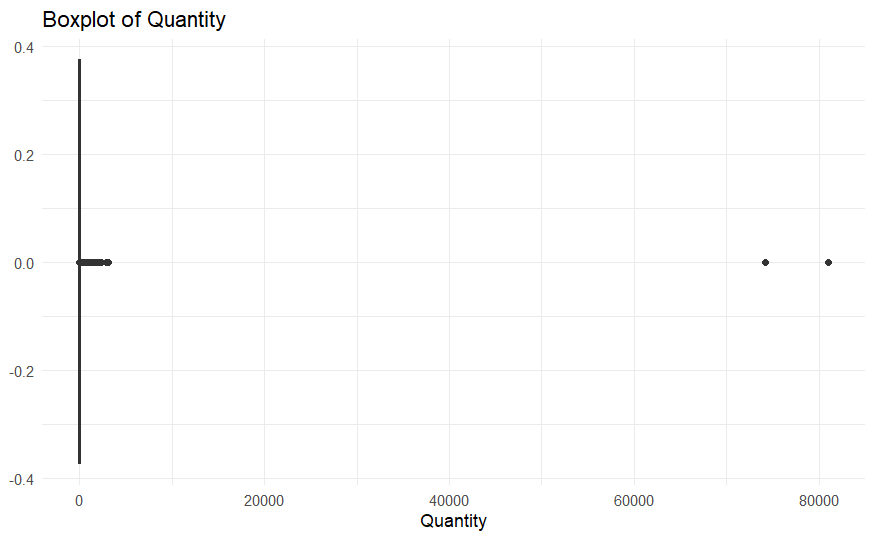

```r
# Boxplot of Quantities
ggplot(df_clean, aes(x = Quantity)) +
  geom_boxplot() +
  labs(
    title = "Boxplot of Quantity",
    x = "Quantity"
  ) +
  theme_minimal()
```

*Explanation:* The boxplot of ‘Quantity’ column showed 2 quantities deviated greatly from normal. These if kept in the analysis will also provide unreliable results.

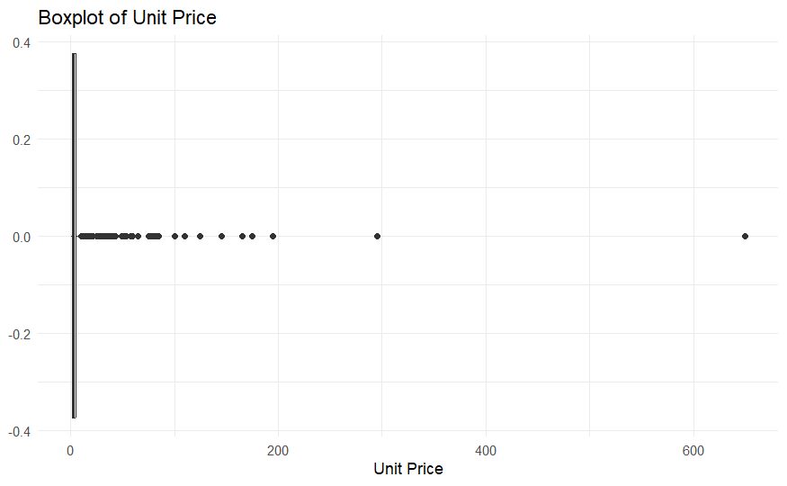

```r
# Boxplot of Unit Prices
ggplot(df_clean, aes(x = UnitPrice)) +
  geom_boxplot() +
  labs(
    title = "Boxplot of Unit Price",
    x = "Unit Price"
  ) +
  theme_minimal()
```

*Explanation:* The boxplot of ‘Unit Price’ column proved that 2 unit prices deviated greatly from normal. These if kept in the analysis will also provide unreliable results.

```r
# Find Quartiles of Quantity
Q1_quantity <- quantile(df_clean$Quantity, 0.25, na.rm = TRUE)
Q3_quantity <- quantile(df_clean$Quantity, 0.75, na.rm = TRUE)

IQR_quantity <- Q3_quantity - Q1_quantity

IQR_quantity
```

```
75%
  7
```

*Explanation:* The interquartile range for ‘Quantity’ of 7 proves that there is a small spread of the middle 50% of the data.

```r
# Find Quartiles of Unit Price
Q1_price <- quantile(df_clean$UnitPrice, 0.25, na.rm = TRUE)
Q3_price <- quantile(df_clean$UnitPrice, 0.75, na.rm = TRUE)

IQR_price <- Q3_price - Q1_price

IQR_price
```

```
75%
3.3
```

*Explanation:* The interquartile range for ‘Unit Price’ of 3.3 proves that there is a very small spread of the middle 50% of the data.

```r
# Calculate lower and upper limits for Quantity
quantity_lower <- Q1_quantity - 1.5 * IQR_quantity
quantity_upper <- Q3_quantity + 1.5 * IQR_quantity

# Calculate lower and upper limits for UnitPrice
price_lower <- Q1_price - 1.5 * IQR_price
price_upper <- Q3_price + 1.5 * IQR_price

# Remove observations outside the limits
df_clean <- df_clean %>%
  filter(
    Quantity >= quantity_lower,
    Quantity <= quantity_upper,
    UnitPrice >= price_lower,
    UnitPrice <= price_upper
  )
```

*Explanation:* Rows outside of the interquartile boundaries for ‘Quantity’ and ‘Unit Price’ were excluded to avoid the extreme values from influencing the analysis.

```r
# Display updated dataset structure
dim(df_clean)
```

```
[1] 356207      8
```

*Explanation:* After dropping the rows with extreme values, 356207 rows and 8 columns are remaining.

```r
# Count unique countries
n_distinct(df_clean$Country)
```

```
[1] 38
```

*Explanation:* 38 different countries were identified in the dataset.

```r
# Display all unique products
unique_products <- df_clean %>%
  select(StockCode, Description) %>%
  distinct() %>%
  arrange(Description)

# Display the unique products
unique_products
```

| StockCode | Description |
| --- | --- |
| 20954 | *USB Office Mirror Ball |
| 22418 | 10 COLOUR SPACEBOY PEN |
| 22436 | 12 COLOURED PARTY BALLOONS |
| 21448 | 12 DAISY PEGS IN WOOD BOX |
| 23442 | 12 HANGING EGGS HAND PAINTED |
| 21447 | 12 IVORY ROSE PEG PLACE SETTINGS |
| 22906 | 12 MESSAGE CARDS WITH ENVELOPES |
| 20973 | 12 PENCIL SMALL TUBE WOODLAND |
| 20975 | 12 PENCILS SMALL TUBE RED RETROSPOT |
| 20974 | 12 PENCILS SMALL TUBE SKULL |

[output cut: 990 more lines]

```r
# Calculate revenue for each transaction
df_clean$Sales <- df_clean$Quantity * df_clean$UnitPrice

# Display the first few records
head(df_clean[, c(
  "InvoiceNo",
  "Description",
  "Quantity",
  "UnitPrice",
  "Sales"
)])
```

| InvoiceNo | Description | Quantity | UnitPrice | Sales |
| --- | --- | --- | --- | --- |
| 536365 | WHITE HANGING HEART T-LIGHT HOLDER | 6 | 2.55 | 15.30 |
| 536365 | WHITE METAL LANTERN | 6 | 3.39 | 20.34 |
| 536365 | CREAM CUPID HEARTS COAT HANGER | 8 | 2.75 | 22.00 |
| 536365 | KNITTED UNION FLAG HOT WATER BOTTLE | 6 | 3.39 | 20.34 |
| 536365 | RED WOOLLY HOTTIE WHITE HEART. | 6 | 3.39 | 20.34 |
| 536365 | SET 7 BABUSHKA NESTING BOXES | 2 | 7.65 | 15.30 |

*Explanation:* The revenue, ‘Quantity’ x ‘UnitPrice’, was calculated to provide the retail store’s management a sound basis for determining sales performance besides number of products sold.

```r
# Convert InvoiceDate to Date format
df_clean$Date <- as.Date(
  df_clean$InvoiceDate
)

# Display the first few dates
head(df_clean$Date)
```

```
[1] "2010-12-01" "2010-12-01" "2010-12-01" "2010-12-01" "2010-12-01" "2010-12-01"
```

*Explanation:* The ‘InvoiceDate’ column has both date and time values. Only the date aspect is needed for further analysis to see how sales changes over time.

```r
# Find the earliest transaction date
min(df_clean$Date)
```

```
[1] "2010-12-01"
```

```r
# Find the latest transaction date
max(df_clean$Date)
```

```
[1] "2011-12-09"
```

*Explanation:* The earliest and latest dates in the dataset are examined to become familiar with the date range of the analysis and for better understanding of sales growth and/or decline patterns.

```r
# Calculate daily sales
daily_sales <- df_clean %>%
  group_by(Date) %>%
  summarise(
    Total_Sales = sum(Sales, na.rm = TRUE)
  )

# Display the first records
head(daily_sales)
```

| Date | Total_Sales |
| --- | --- |
| 2010-12-01 | 23716.09 |
| 2010-12-02 | 19525.48 |
| 2010-12-03 | 18821.40 |
| 2010-12-05 | 18679.71 |
| 2010-12-06 | 28908.30 |
| 2010-12-07 | 25392.03 |

*Explanation:* Through assessing daily sales, it be an indication to the retail store’s owners of the typical day(s) vs non-typical days for purchases.

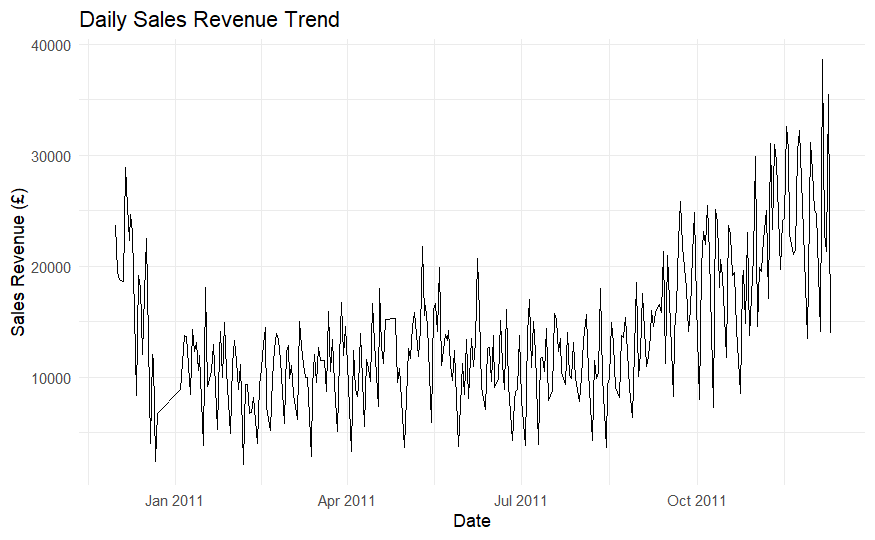

```r
# Display daily sales
ggplot(
  daily_sales,
  aes(
    x = Date,
    y = Total_Sales
  )
) +
  geom_line() +
  labs(
    title = "Daily Sales Revenue Trend",
    x = "Date",
    y = "Sales Revenue (£)"
  ) +
  theme_minimal()
```

*Explanation:* The daily sales revenue trend over 2010-2011 show primarily sharp rises and falls in sales. There is a staggered fall in sales in late 2010 and a gradual yet staggered increase in sales in late 2011 (roughly Nov to Dec). For the retail store, these rises and falls could be due to rapidly changing customer demands, attractive and/or unattractive sales promotions, inventory shortages or operational disruptions (e.g. website/payment system downtime, delivery delays).

```r
# Calculate monthly sales
df_clean$YearMonth <- format(
  df_clean$Date,
  "%Y-%m"
)

monthly_sales <- df_clean %>%
  group_by(YearMonth) %>%
  summarise(
    Total_Sales = sum(
      Sales,
      na.rm = TRUE
    )
  )

head(monthly_sales)
```

| YearMonth | Total_Sales |
| --- | --- |
| 2010-12 | 339693.4 |
| 2011-01 | 266619.6 |
| 2011-02 | 231309.4 |
| 2011-03 | 295317.4 |
| 2011-04 | 234846.6 |
| 2011-05 | 326801.7 |

*Explanation:* Through assessing monthly sales, the retail store’s owners can use this data for more strategic planning (eg. increasing inventory given repeated demand) and to be informed of sales influenced by seasons (eg. shopping for national holidays like Christmas).

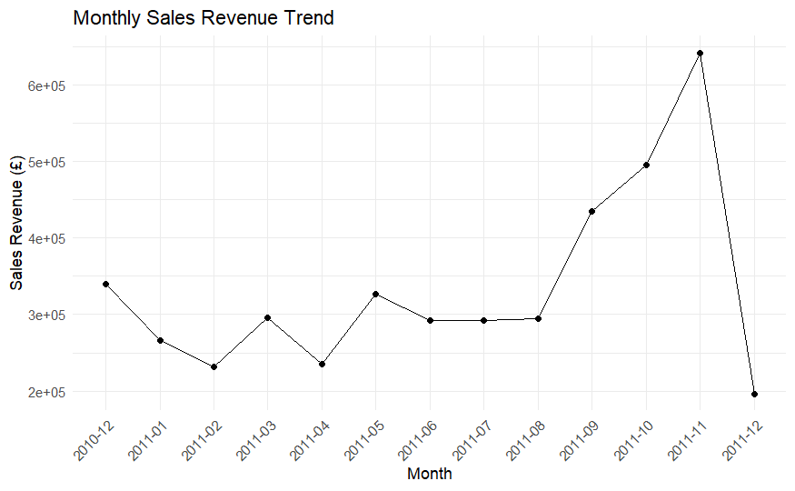

```r
# Plot monthly sales
ggplot(
  monthly_sales,
  aes(
    x = YearMonth,
    y = Total_Sales,
    group = 1
  )
) +
  geom_line() +
  geom_point() +
  labs(
    title = "Monthly Sales Revenue Trend",
    x = "Month",
    y = "Sales Revenue (£)"
  ) +
  theme_minimal() +
  theme(
    axis.text.x = element_text(
      angle = 45,
      hjust = 1
    )
  )
```

*Explanation:* The monthly sales revenue trend for the retail store shows that it had lower sales in Dec 2010 to Aug 2011. This pattern could be attributed to weak customer demand and/or promotion by the retail store. Its sales increased after Aug 2011 to Nov 2011 then declined dramatically again in Dec 2011. This is an expected demand pattern nearing holiday seasons except for the decline in Dec 2011 which needs more context to explain.

```r
# Identify the best sales months
top_months <- monthly_sales[
  order(
    monthly_sales$Total_Sales,
    decreasing = TRUE
  ),
]

head(top_months, 10)
```

| YearMonth | Total_Sales |
| --- | --- |
| 2011-11 | 641792.3 |
| 2011-10 | 494707.4 |
| 2011-09 | 434966.2 |
| 2010-12 | 339693.4 |
| 2011-05 | 326801.7 |
| 2011-03 | 295317.4 |
| 2011-08 | 294970.4 |
| 2011-06 | 292457.5 |
| 2011-07 | 291629.7 |
| 2011-01 | 266619.6 |

*Explanation:* The best sales months were primarily in the 3rd and 4th quarters of the years. Though, not certain, this could be due to greater customer demand (local and international) given additional promotions, new product launches or changes to customer buying patterns.

```r
# Identify the weakest sales months
bottom_months <- monthly_sales[
  order(
    monthly_sales$Total_Sales,
    decreasing = FALSE
  ),
]

head(bottom_months, 10)
```

| YearMonth | Total_Sales |
| --- | --- |
| 2011-12 | 196308.7 |
| 2011-02 | 231309.4 |
| 2011-04 | 234846.6 |
| 2011-01 | 266619.6 |
| 2011-07 | 291629.7 |
| 2011-06 | 292457.5 |
| 2011-08 | 294970.4 |
| 2011-03 | 295317.4 |
| 2011-05 | 326801.7 |
| 2010-12 | 339693.4 |

```r
# Calculate sales by year
df_clean$Year <- format(
  df_clean$Date,
  "%Y"
)

yearly_sales <- df_clean %>%
  group_by(Year) %>%
  summarise(
    Total_Sales = sum(
      Sales,
      na.rm = TRUE
    )
  )

yearly_sales
```

| Year | Total_Sales |
| --- | --- |
| 2010 | 339693.4 |
| 2011 | 4001726.9 |

*Explanation:* This yearly sales data provides the retail store’s owners with a high level view of revenue. However, as 2010 only has one month represented in the dataset, this imbalance gives favour to higher sales in 2011. Consequently, the results are unsuitable for determining true demand for either years.

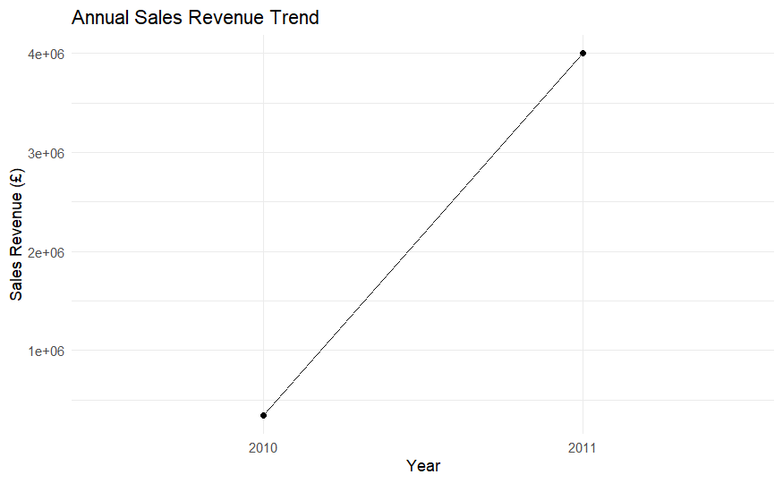

```r
# Plot yearly sales
ggplot(
  yearly_sales,
  aes(
    x = Year,
    y = Total_Sales,
    group = 1
  )
) +
  geom_line() +
  geom_point() +
  labs(
    title = "Annual Sales Revenue Trend",
    x = "Year",
    y = "Sales Revenue (£)"
  ) +
  theme_minimal()
```

*Explanation:* The data shows an increase in yearly sales from 2010 to 2011 for the retail store; almost 12 times that of 2010. Yet, this is fostered by a dataset imbalance.

```r
# Analyze sales by day of the week
df_clean$DayOfWeek <- weekdays(
  df_clean$Date
)

day_sales <- df_clean %>%
  group_by(DayOfWeek) %>%
  summarise(
    Total_Sales = sum(
      Sales,
      na.rm = TRUE
    )
  )

day_sales
```

| DayOfWeek | Total_Sales |
| --- | --- |
| Friday | 699910.0 |
| Monday | 733881.4 |
| Sunday | 447203.0 |
| Thursday | 880819.5 |
| Tuesday | 817319.3 |
| Wednesday | 762287.1 |

*Explanation:* An analysis of the sales per day of the week helps the retail store’s owners to identify the weekday(s) that see the most versus least revenue. The store’s owners may then dynamically adjust staffing and efficiency to fulfill orders, timing of promotions and advertising and inventory reorder schedules.

```r
# Put weekdays in the correct order
day_sales$DayOfWeek <- factor(
  day_sales$DayOfWeek,
  levels = c(
    "Monday",
    "Tuesday",
    "Wednesday",
    "Thursday",
    "Friday",
    "Saturday",
    "Sunday"
  )
)

day_sales <- day_sales[
  order(day_sales$DayOfWeek),
]
```

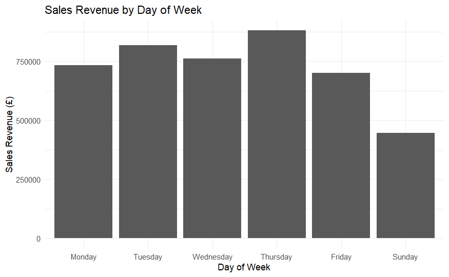

```r
# Plot sales by day of week
ggplot(
  day_sales,
  aes(
    x = DayOfWeek,
    y = Total_Sales
  )
) +
  geom_bar(
    stat = "identity"
  ) +
  labs(
    title = "Sales Revenue by Day of Week",
    x = "Day of Week",
    y = "Sales Revenue (£)"
  ) +
  theme_minimal()
```

*Explanation:* Tuesdays and Thursdays reflect similar revenue and the highest revenues. Mondays, Wednesdays and Fridays also had similar but lower revenue with Sunday having the lowest revenue. The retail store’s owners may apply any or some of the strategies as previously suggested to capitalize on the “high revenue” days or boost sales on “low revenue” days.

```r
# Analyze monthly seasonality
df_clean$Month <- format(
  df_clean$Date,
  "%m"
)

monthly_seasonality <- df_clean %>%
  group_by(Month) %>%
  summarise(
    Total_Sales = sum(
      Sales,
      na.rm = TRUE
    )
  )

monthly_seasonality
```

| Month | Total_Sales |
| --- | --- |
| 01 | 266619.6 |
| 02 | 231309.4 |
| 03 | 295317.4 |
| 04 | 234846.6 |
| 05 | 326801.7 |
| 06 | 292457.5 |
| 07 | 291629.7 |
| 08 | 294970.4 |
| 09 | 434966.2 |
| 10 | 494707.4 |

[output cut: 2 more lines]

*Explanation:* Monthly seasonality helps the retail store’s owners identify which month(s) overall had the best sales, specifically seasonality patterns. Therefore, the owners could implement strategies including acquiring adequate stock for the season, increase advertising/marketing efforts and optimizing order fulfillment operations ahead of these peak seasons.

```r
# Order the months correctly
monthly_seasonality$Month <- factor(
  monthly_seasonality$Month,
  levels = c(
    "01", "02", "03", "04",
    "05", "06", "07", "08",
    "09", "10", "11", "12"
  )
)

monthly_seasonality <- monthly_seasonality[
  order(monthly_seasonality$Month),
]
```

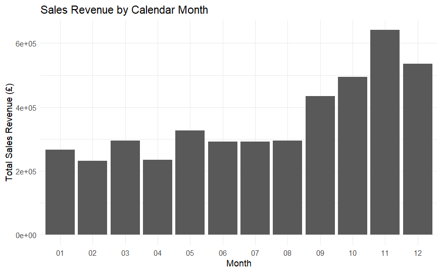

```r
# Plot monthly seasonality
ggplot(
  monthly_seasonality,
  aes(
    x = Month,
    y = Total_Sales
  )
) +
  geom_bar(
    stat = "identity"
  ) +
  labs(
    title = "Sales Revenue by Calendar Month",
    x = "Month",
    y = "Total Sales Revenue (£)"
  ) +
  theme_minimal()
```

```r
# Analyze international sales
country_sales <- df_clean %>%
  group_by(Country) %>%
  summarise(
    Total_Sales = sum(
      Sales,
      na.rm = TRUE
    )
  ) %>%
  arrange(
    desc(Total_Sales)
  )

head(country_sales, 10)
```

| Country | Total_Sales |
| --- | --- |
| United Kingdom | 3824428.75 |
| Germany | 112048.66 |
| EIRE | 97781.80 |
| France | 95621.28 |
| Spain | 25233.63 |
| Switzerland | 24192.41 |
| Belgium | 24170.98 |
| Portugal | 16111.71 |
| Norway | 14674.99 |
| Netherlands | 11446.01 |

*Explanation:* Most of the online retail store’s sales are generated from its base country, the United Kingdom. This may be in its owners’ best favour as their marketing and shipping efforts can be minimal. However, this also presents a grand opportunity for greater international, country-specific marketing and improving shipping operations, therefore catering to a wider customer base.

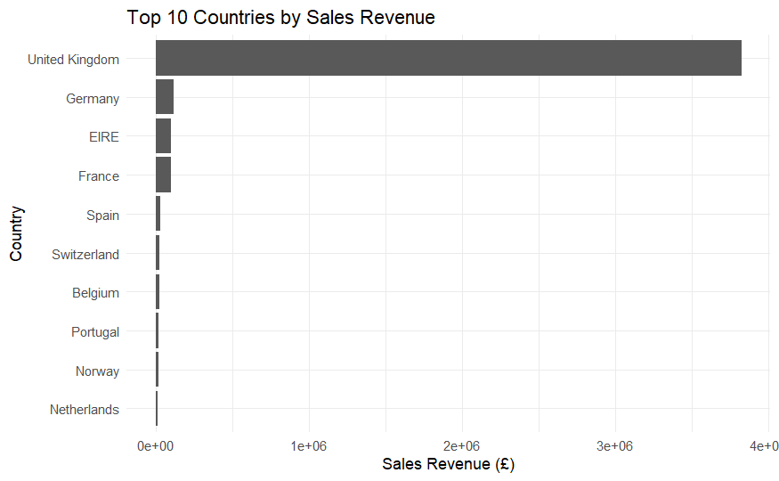

```r
# Plot the top 10 countries
top_countries <- head(
  country_sales,
  10
)

ggplot(
  top_countries,
  aes(
    x = reorder(
      Country,
      Total_Sales
    ),
    y = Total_Sales
  )
) +
  geom_bar(
    stat = "identity"
  ) +
  coord_flip() +
  labs(
    title = "Top 10 Countries by Sales Revenue",
    x = "Country",
    y = "Sales Revenue (£)"
  ) +
  theme_minimal()
```

```r
# Find the highest selling products
product_sales <- df_clean %>%
  group_by(
    StockCode,
    Description
  ) %>%
  summarise(
    Total_Sales = sum(
      Sales,
      na.rm = TRUE
    )
  ) %>%
  arrange(
    desc(Total_Sales)
  )

head(product_sales, 10)
```

| StockCode | Description | Total_Sales |
| --- | --- | --- |
| 47566 | PARTY BUNTING | 33175.65 |
| 85123A | WHITE HANGING HEART T-LIGHT HOLDER | 32139.11 |
| 85099B | JUMBO BAG RED RETROSPOT | 24142.42 |
| 22960 | JAM MAKING SET WITH JARS | 23919.30 |
| 23298 | SPOTTY BUNTING | 22060.05 |
| 22457 | NATURAL SLATE HEART CHALKBOARD | 20110.41 |
| 84879 | ASSORTED COLOUR BIRD ORNAMENT | 18952.95 |
| 22086 | PAPER CHAIN KIT 50'S CHRISTMAS | 18687.07 |
| 22726 | ALARM CLOCK BAKELIKE GREEN | 18599.16 |
| 22727 | ALARM CLOCK BAKELIKE RED | 18591.17 |

*Explanation:* An analysis of the overall revenue per product can aid the retail store’s owners in identifying the popular products, focusing inventory restock efforts, further promoting the “high sales” products and investigating the “low sales” products.

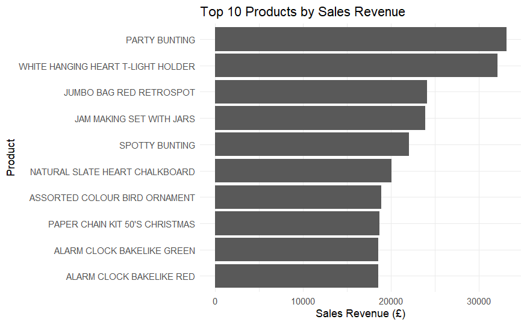

```r
# Plot the top 10 products
top_products <- head(
  product_sales,
  10
)

ggplot(
  top_products,
  aes(
    x = reorder(
      Description,
      Total_Sales
    ),
    y = Total_Sales
  )
) +
  geom_bar(
    stat = "identity"
  ) +
  coord_flip() +
  labs(
    title = "Top 10 Products by Sales Revenue",
    x = "Product",
    y = "Sales Revenue (£)"
  ) +
  theme_minimal()
```

*Explanations:* The retail store owner’s sales efforts across international markets could be centred around these 10 products to capitalize on their high revenue potential.

```r
# Calculate total sales for each product within each country
country_product_sales <- df_clean %>%
  group_by(Country, StockCode, Description) %>%
  summarise(
    Total_Sales = sum(Sales, na.rm = TRUE),
    .groups = "drop"
  )

# View the results
head(country_product_sales)
```

| Country | StockCode | Description | Total_Sales |
| --- | --- | --- | --- |
| Australia | 15056BL | EDWARDIAN PARASOL BLACK | 17.85 |
| Australia | 20665 | RED RETROSPOT PURSE | 17.70 |
| Australia | 20685 | DOORMAT RED RETROSPOT | 79.50 |
| Australia | 20712 | JUMBO BAG WOODLAND ANIMALS | 61.10 |
| Australia | 20713 | JUMBO BAG OWLS | 19.50 |
| Australia | 20717 | STRAWBERRY SHOPPER BAG | 12.50 |

*Explanation:* Through examining the product sales per country, the retail store’s owners can better understand the demand distribution. Therefore, they can optimize inventory and shipping operations to ensure these products are readily available and delivered on time.

```r
# Find the highest-selling product in each country
highest_product_by_country <- country_product_sales %>%
  group_by(Country) %>%
  slice_max(
    order_by = Total_Sales,
    n = 1,
    with_ties = FALSE
  ) %>%
  ungroup()

# Display the results
highest_product_by_country
```

| Country | StockCode | Description | Total_Sales |
| --- | --- | --- | --- |
| Australia | 48138 | DOORMAT UNION FLAG | 266.70 |
| Austria | 15056P | EDWARDIAN PARASOL PINK | 142.80 |
| Bahrain | 22649 | STRAWBERRY FAIRY CAKE TEAPOT | 39.60 |
| Belgium | 22326 | ROUND SNACK BOXES SET OF4 WOODLAND | 743.40 |
| Brazil | 22366 | DOORMAT AIRMAIL | 67.50 |
| Canada | 21558 | SKULL LUNCH BOX WITH CUTLERY | 45.90 |
| Channel Islands | 21621 | VINTAGE UNION JACK BUNTING | 187.00 |
| Cyprus | 82484 | WOOD BLACK BOARD ANT WHITE FINISH | 146.10 |
| Czech Republic | 21428 | SET3 BOOK BOX GREEN GINGHAM FLOWER | 51.00 |
| Denmark | 23256 | CHILDRENS CUTLERY SPACEBOY | 149.40 |

[output cut: 28 more lines]

*Explanation:* The highest-selling product per country provides the retail store’s owners with insight into which product contributes most to its revenue. Its owners may then employ additional advertising strategies (eg. social media/tv ads) to drive more sales of these products.

```r
# Calculate quantity sold for each product within each country
country_product_quantity <- df_clean %>%
  group_by(Country, StockCode, Description) %>%
  summarise(
    Total_Quantity = sum(Quantity, na.rm = TRUE),
    .groups = "drop"
  )

# Find the product with the highest quantity sold in each country
highest_quantity_by_country <- country_product_quantity %>%
  group_by(Country) %>%
  slice_max(
    order_by = Total_Quantity,
    n = 1,
    with_ties = FALSE
  ) %>%
  ungroup()

highest_quantity_by_country
```

| Country | StockCode | Description | Total_Quantity |
| --- | --- | --- | --- |
| Australia | 22087 | PAPER BUNTING WHITE LACE | 48 |
| Austria | 22326 | ROUND SNACK BOXES SET OF4 WOODLAND | 36 |
| Bahrain | 85040A | S/4 PINK FLOWER CANDLES IN BOWL | 12 |
| Belgium | 22326 | ROUND SNACK BOXES SET OF4 WOODLAND | 252 |
| Brazil | 21166 | COOK WITH WINE METAL SIGN | 12 |
| Canada | 23190 | BUNDLE OF 3 SCHOOL EXERCISE BOOKS | 24 |
| Channel Islands | 20725 | LUNCH BAG RED RETROSPOT | 70 |
| Cyprus | 21974 | SET OF 36 PAISLEY FLOWER DOILIES | 24 |
| Czech Republic | 22930 | BAKING MOULD HEART MILK CHOCOLATE | 18 |
| Denmark | 22629 | SPACEBOY LUNCH BOX | 72 |

[output cut: 28 more lines]

*Explanation:* The highest-selling product per country and product with highest quantity sold per country differ. Yet, the retail store’s owners can still capitalize on maintaining adequate inventory levels as these products still contribute to revenue though to a smaller degree.

```r
# Calculate the number of orders by month
monthly_orders <- df_clean %>%
  group_by(YearMonth) %>%
  summarise(
    Number_of_Orders = length(
      unique(InvoiceNo)
    )
  )

head(monthly_orders)
```

| YearMonth | Number_of_Orders |
| --- | --- |
| 2010-12 | 1365 |
| 2011-01 | 965 |
| 2011-02 | 972 |
| 2011-03 | 1296 |
| 2011-04 | 1087 |
| 2011-05 | 1466 |

*Explanation:* The number of orders per month aids the retail store’s owners in differentiating between more customers or more orders versus larger orders from existing customers.

```r
# Compare monthly revenue with monthly orders
monthly_summary <- merge(
  monthly_sales,
  monthly_orders,
  by = "YearMonth"
)

head(monthly_summary)
```

|  | YearMonth | Total_Sales | Number_of_Orders |
| --- | --- | --- | --- |
| 1 | 2010-12 | 339693.4 | 1365 |
| 2 | 2011-01 | 266619.6 | 965 |
| 3 | 2011-02 | 231309.4 | 972 |
| 4 | 2011-03 | 295317.4 | 1296 |
| 5 | 2011-04 | 234846.6 | 1087 |
| 6 | 2011-05 | 326801.7 | 1466 |

*Explanation:* The retail store’s owners can get a better understanding of monthly sales performance through a side-by-side view of sales and number of orders. From a glance at this data, it appears a few orders generate much revenue per month.

```r
# Calculate average order value
monthly_summary$Average_Order_Value <-
  monthly_summary$Total_Sales /
  monthly_summary$Number_of_Orders

head(monthly_summary)
```

|  | YearMonth | Total_Sales | Number_of_Orders | Average_Order_Value |
| --- | --- | --- | --- | --- |
| 1 | 2010-12 | 339693.4 | 1365 | 248.8597 |
| 2 | 2011-01 | 266619.6 | 965 | 276.2897 |
| 3 | 2011-02 | 231309.4 | 972 | 237.9726 |
| 4 | 2011-03 | 295317.4 | 1296 | 227.8683 |
| 5 | 2011-04 | 234846.6 | 1087 | 216.0503 |
| 6 | 2011-05 | 326801.7 | 1466 | 222.9207 |

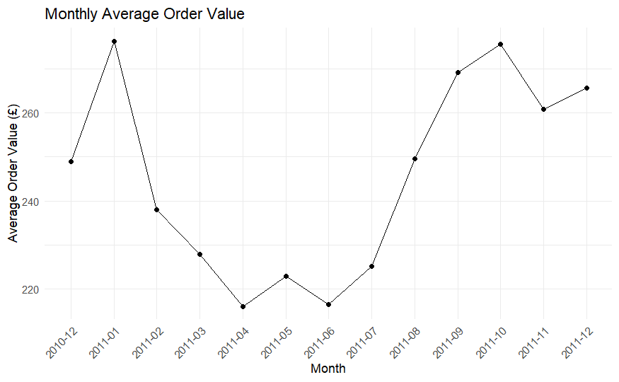

```r
# Plot average order value
ggplot(
  monthly_summary,
  aes(
    x = YearMonth,
    y = Average_Order_Value,
    group = 1
  )
) +
  geom_line() +
  geom_point() +
  labs(
    title = "Monthly Average Order Value",
    x = "Month",
    y = "Average Order Value (£)"
  ) +
  theme_minimal() +
  theme(
    axis.text.x = element_text(
      angle = 45,
      hjust = 1
    )
  )
```

*Explanation:* The data shows that customers spent varying amounts on orders over 2010-2011. The greatest spend were in Jan 2011 and Oct 2011, with a drastic decrease from Feb 2011 to Jul 2011. The low points were prime opportunities for the store’s owners to implement product bundling, cross-selling/upselling, discounts and other promotions to improve sales.

```r
# Calculate customer-level sales measures
customer_value <- df_clean %>%
  filter(!is.na(CustomerID)) %>%
  group_by(CustomerID) %>%
  summarise(
    Total_Sales = sum(Sales, na.rm = TRUE),
    Number_of_Orders = n_distinct(InvoiceNo),
    Total_Quantity = sum(Quantity, na.rm = TRUE),
    Average_Order_Value = Total_Sales / Number_of_Orders,
    .groups = "drop"
  )

# Find the customer with the highest total sales
most_valuable_customer <- customer_value %>%
  slice_max(
    order_by = Total_Sales,
    n = 1,
    with_ties = FALSE
  )

most_valuable_customer
```

| CustomerID | Total_Sales | Number_of_Orders | Total_Quantity | Average_Order_Value |
| --- | --- | --- | --- | --- |
| 14911 | 71856.09 | 191 | 26425 | 376.2099 |

*Explanation:* Customer with ID# 14911 was identified as the “most valuable customer” during the period and therefore could be extended special offers like free shipping once per month or coupons to encourage their continued patronage to the retail store.

```r
# Find the top 10 customers by total sales
top_10_customers <- customer_value %>%
  arrange(desc(Total_Sales)) %>%
  head(10)

# Display the results
top_10_customers
```

| CustomerID | Total_Sales | Number_of_Orders | Total_Quantity | Average_Order_Value |
| --- | --- | --- | --- | --- |
| 14911 | 71856.09 | 191 | 26425 | 376.20990 |
| 14096 | 35914.24 | 17 | 11093 | 2112.60235 |
| 17841 | 28270.68 | 123 | 11667 | 229.84293 |
| 13089 | 25778.43 | 81 | 9199 | 318.25222 |
| 12748 | 16038.01 | 181 | 6497 | 88.60779 |
| 14156 | 14941.55 | 37 | 4758 | 403.82568 |
| 14088 | 14604.34 | 13 | 2844 | 1123.41077 |
| 15311 | 13889.20 | 91 | 4889 | 152.62857 |
| 17675 | 13274.21 | 31 | 4466 | 428.20032 |
| 15039 | 12997.87 | 47 | 4927 | 276.55043 |

*Explanation:* These customers constitute the retail store’s “high-revenue customer group”. Likewise, they could be extended special offers to maintain their loyalty.

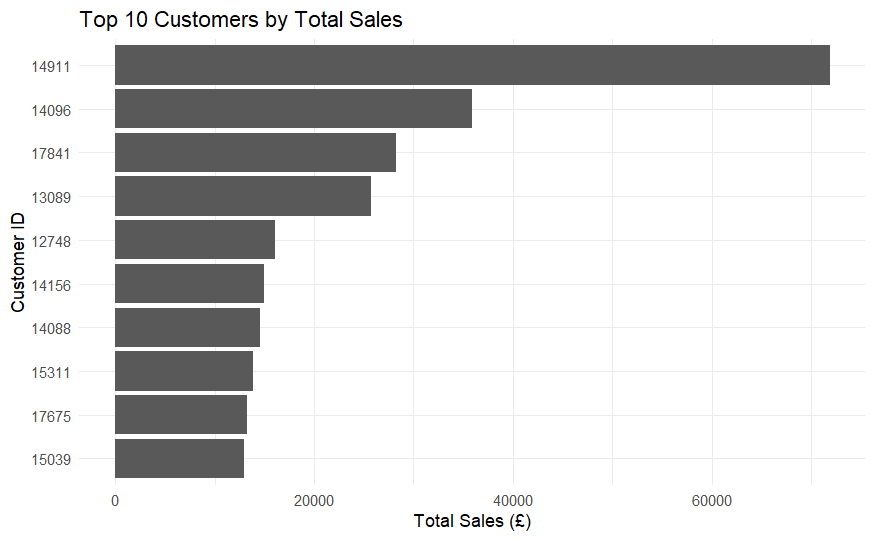

```r
ggplot(
  top_10_customers,
  aes(
    x = reorder(
      as.factor(CustomerID),
      Total_Sales
    ),
    y = Total_Sales
  )
) +
  geom_bar(
    stat = "identity"
  ) +
  coord_flip() +
  labs(
    title = "Top 10 Customers by Total Sales",
    x = "Customer ID",
    y = "Total Sales (£)"
  ) +
  theme_minimal()
```

```r
# Useful final management summary
total_revenue <- sum(
  df_clean$Sales,
  na.rm = TRUE
)

total_orders <- length(
  unique(df_clean$InvoiceNo)
)

total_products_sold <- sum(
  df_clean$Quantity,
  na.rm = TRUE
)

average_order_value <-
  total_revenue / total_orders

cat(
  "Total Revenue: £",
  round(total_revenue, 2),
  "\n"
)
```

```
Total Revenue: £ 4341420
```

```r
cat(
  "Total Orders:",
  total_orders,
  "\n"
)
```

```
Total Orders: 17590
```

```r
cat(
  "Total Products Sold:",
  total_products_sold,
  "\n"
)
```

```
Total Products Sold: 1580945
```

```r
cat(
  "Average Order Value: £",
  round(average_order_value, 2),
  "\n"
)
```

```
Average Order Value: £ 246.81
```